# Week 6, Lecture 11 Advanced statistical methods, part II: Structural equation modeling, social network analysis, and geospatial analyses

## Social network analysis

To have a data set to explore as a first look into social networks, we’ll use data on a Northern Alaskan community helping network from the following paper:

Lee, H. W., et al. (2018). Mapping the structure of perceptions in helping networks of Alaska Natives. PLOS ONE, 13(11), e0204343. doi: 10.1371/journal.pone.0204343

In the Supporting Information, download “S1 File” and extract “Edge data.csv” to your `/data` folder: https://journals.plos.org/plosone/article?id=10.1371/journal.pone.0204343#sec016

A little network data terminology: networks are made up of nodes and edges. Nodes are the individual points in the network, usually people, and are often represented as numerical IDs. Edges are the connections between nodes, and can represent any kind of association or interaction (time spent together, citations, etc.). When we read in the data, we can have separate lists of nodes and edges, and edge lists often contain other variables that relate to the links between nodes.

There are two types of networks: directed and undirected. In directed networks, the edges have a direction, e.g. A does something to B. In undirected networks, A is connected to B, but there is no direction to the connection, they’re just associated.

Here, all we have is an edge list and, from the paper, it’s directed (A helps B). We read it in:

```r
helpnet = read.csv("./data/Edge data.csv")
```

```r
head(helpnet)
```

```
##   NodeA.01. NodeB.02. Saw_AB.15. Rec_AB.16. Diff_AB.17. Same_AB
## 1       144       210          9          6           5       1
## 2       210       144          9          6           5       1
## 3       283       385          9          8           6       2
## 4       385       283          9          8           6       2
## 5      -170        92          8          7           5       2
## 6      -143       144          8          3           1       2
##   Avg_Dist.18. Std_Dist.19.
## 1    0.4906949    0.1013380
## 2    0.4906949    0.1013380
## 3    0.3279706    0.2976857
## 4    0.3279706    0.2976857
## 5    0.5479487    0.3182149
## 6    0.3696195    0.0000000
```

We can see the network has some negative values for the nodes.

```r
summary(helpnet$NodeA.01.)
```

```
##    Min. 1st Qu.  Median    Mean 3rd Qu.    Max.
## -172.00  -49.00   85.00   97.74  250.00  395.00
```

```r
summary(helpnet$NodeB.02.)
```

```
##    Min. 1st Qu.  Median    Mean 3rd Qu.    Max.
## -172.00  -46.00   86.00   99.31  250.00  395.00
```

This is actually what’s called a “signed” network, in that it has edges with positive and negative signs. Positive values represent positive interactions (from the paper: “e.g. liking, loving, supporting”) and negative interactions (“disliking, hating, opposing”). To simplify things here, we’re just going to look at the positive edges.

```r
helpnetP = helpnet[helpnet$NodeA.01. > 0 & helpnet$NodeB.02. > 0,]
dim(helpnetP)
```

```
## [1] 64262     8
```

```r
length(unique(unname(unlist(helpnetP[,1:2]))))
```

```
## [1] 254
```

Looks like it’s still a very big network, with 64,262 connections between 254 nodes.

There are a number of social network packages in R, the main ones being `network`, `sna`, and `igraph`. Here we’ll use `igraph` because it seems to be the most commonly used package, and is also cross-platform with other programming languages such as Python. But depending on your analyses and your needs, feel free to check the others out too.

```r
install.packages("igraph")
```

```r
library(igraph)
```

We’ll use the `graph_from_data_frame()` function to make our data frame into an igraph object.

```r
?graph_from_data_frame
```

```r
helpnetG = graph_from_data_frame(helpnetP)
helpnetG
```

```
## IGRAPH 0ac62c8 DN-- 254 64262 --
## + attr: name (v/c), Saw_AB.15. (e/n), Rec_AB.16. (e/n),
## | Diff_AB.17. (e/n), Same_AB (e/n), Avg_Dist.18. (e/n),
## | Std_Dist.19. (e/n)
## + edges from 0ac62c8 (vertex names):
##  [1] 144->210 210->144 283->385 385->283 20 ->335 132->283 199->269
##  [8] 223->362 269->199 283->132 335->20  362->223 5  ->258 53 ->310
## [15] 74 ->202 74 ->208 146->199 151->302 181->283 199->146 202->74
## [22] 208->74  210->286 223->315 223->331 234->301 258->5   259->385
## [29] 283->181 286->210 290->392 301->234 302->151 310->53  315->223
## [36] 320->331 331->223 331->320 385->259 392->290 5  ->84  5  ->98
## + ... omitted several edges
```

Looks like it loaded in correctly. We can see the other variables from the data frame as attributes, and the beginning of the edge list, with direction indicated. We can get vectors of the nodes (in `igraph`, called “vertices”) with `V()` and the edges with `E()`.

```r
V(helpnetG)
```

```
## + 254/254 vertices, named, from 0ac62c8:
##   [1] 144 210 283 385 20  132 199 223 269 335 362 5   53  74  146 151 181
##  [18] 202 208 234 258 259 286 290 301 302 310 315 320 331 392 21  33  35
##  [35] 36  38  41  42  46  55  62  63  66  68  71  73  80  83  84  85  92
##  [52] 97  98  101 107 108 109 110 111 117 119 124 127 130 155 157 163 172
##  [69] 173 174 176 180 185 187 190 197 198 203 206 207 220 224 227 228 241
##  [86] 243 245 247 253 255 256 257 261 264 265 266 273 274 275 276 278 292
## [103] 293 296 309 311 314 326 336 337 339 344 349 368 378 384 388 393 395
## [120] 1   2   7   8   9   14  19  23  24  26  31  32  34  44  45  54  58
## [137] 59  65  69  72  76  77  78  86  89  93  99  100 106 112 126 128 131
## [154] 134 135 141 142 145 152 154 158 159 165 166 167 168 169 170 171 175
## + ... omitted several vertices
```

```r
E(helpnetG)
```

```
## + 64262/64262 edges from 0ac62c8 (vertex names):
##  [1] 144->210 210->144 283->385 385->283 20 ->335 132->283 199->269
##  [8] 223->362 269->199 283->132 335->20  362->223 5  ->258 53 ->310
## [15] 74 ->202 74 ->208 146->199 151->302 181->283 199->146 202->74
## [22] 208->74  210->286 223->315 223->331 234->301 258->5   259->385
## [29] 283->181 286->210 290->392 301->234 302->151 310->53  315->223
## [36] 320->331 331->223 331->320 385->259 392->290 5  ->84  5  ->98
## [43] 21 ->385 33 ->227 35 ->132 36 ->174 38 ->185 38 ->187 41 ->84
## [50] 41 ->92  42 ->302 42 ->310 42 ->344 46 ->293 53 ->55  53 ->220
## [57] 53 ->265 55 ->53  55 ->111 55 ->220 55 ->253 55 ->259 55 ->362
## [64] 62 ->326 62 ->368 63 ->243 66 ->80  68 ->180 68 ->368 71 ->296
## + ... omitted several edges
```

If we want to pull out any of the other attributes from our original edge list, we can use the `edge_attr()` function:

```r
edge_attr(helpnetG, "Avg_Dist.18.")[1:10]
```

```
##  [1] 0.4906949 0.4906949 0.3279706 0.3279706 0.5044079 0.4257790 0.2104445
##  [8] 0.5632773 0.2104445 0.4257790
```

If we reference it like a matrix, we can see the connections between nodes:

```r
helpnetG[1,]
```

```
## 144 210 283 385  20 132 199 223 269 335 362   5  53  74 146 151 181 202
##   0   1   1   1   1   1   1   1   1   1   1   1   1   1   1   1   1   1
## 208 234 258 259 286 290 301 302 310 315 320 331 392  21  33  35  36  38
##   1   1   1   1   1   1   1   1   1   1   1   1   1   1   1   1   1   1
##  41  42  46  55  62  63  66  68  71  73  80  83  84  85  92  97  98 101
##   1   1   1   1   1   1   1   1   1   1   1   1   1   1   1   1   1   1
## 107 108 109 110 111 117 119 124 127 130 155 157 163 172 173 174 176 180
##   1   1   1   1   1   1   1   1   1   1   1   1   1   1   1   1   1   1
## 185 187 190 197 198 203 206 207 220 224 227 228 241 243 245 247 253 255
##   1   1   1   1   1   1   1   1   1   1   1   1   1   1   1   1   1   1
## 256 257 261 264 265 266 273 274 275 276 278 292 293 296 309 311 314 326
##   1   1   1   1   1   1   1   1   1   1   1   1   1   1   1   1   1   1
## 336 337 339 344 349 368 378 384 388 393 395   1   2   7   8   9  14  19
##   1   1   1   1   1   1   1   1   1   1   1   1   1   1   1   1   1   1
##  23  24  26  31  32  34  44  45  54  58  59  65  69  72  76  77  78  86
##   1   1   1   1   1   1   1   1   1   1   1   1   1   1   1   1   1   1
##  89  93  99 100 106 112 126 128 131 134 135 141 142 145 152 154 158 159
##   1   1   1   1   1   1   1   1   1   1   1   1   1   1   1   1   1   1
## 165 166 167 168 169 170 171 175 186 193 195 201 204 212 213 216 235 236
##   1   1   1   1   1   1   1   1   1   1   1   1   1   1   1   1   1   1
## 250 260 279 285 294 303 306 307 308 316 318 322 324 325 338 342 343 346
##   1   1   1   1   1   1   1   1   1   1   1   1   1   1   1   1   1   1
## 355 359 364 365 366 367 373 374 377 382 383 386 389  16  22  25  43  52
##   1   1   1   1   1   1   1   1   1   1   1   1   1   1   1   1   1   1
##  64  82  88 129 137 140 149 164 196 205 230 237 238 252 262 281 287 288
##   1   1   1   1   1   1   1   1   1   1   1   1   1   1   1   1   1   1
## 295 299 305 312 313 323 334 341 354 356 358 375  12 182 219 282 289 340
##   1   1   1   1   1   1   1   1   1   1   1   1   1   1   1   1   1   1
## 372 390
##   1   1
```

It looks like every node is connected to every other node. This may not make for a very informative graph, but we can still plot it to take a look:

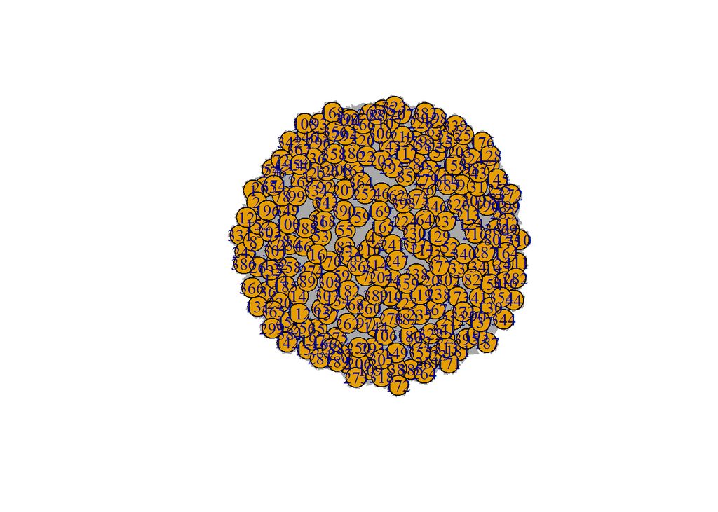

```r
plot(helpnetG)
```

Yep, just a total mess. This can often be a downfall of social network diagrams, in that they can be very pretty, but contain such a high density of information that they don’t really communicate anything (refer back to our resources on information design).

We can try to remedy it by changing the layout of the data:

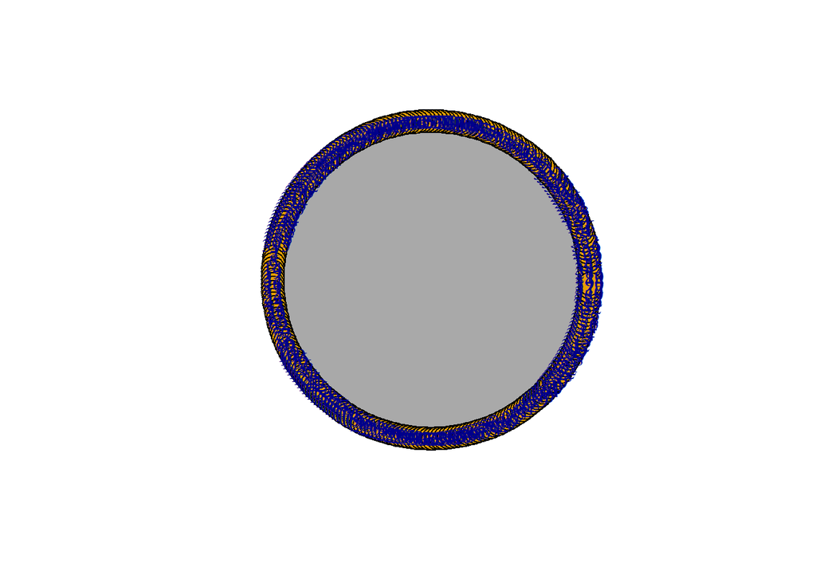

```r
plot(helpnetG, layout=layout_in_circle)
```

Nope. Still a mess. If we had less data, perhaps by looking at meaningful subsets, it could be better. Since all nodes are connected, it would be good to use those attributes to, for instance, display different line weights for our edges. Though we won’t notice a difference here, we could do it like so:

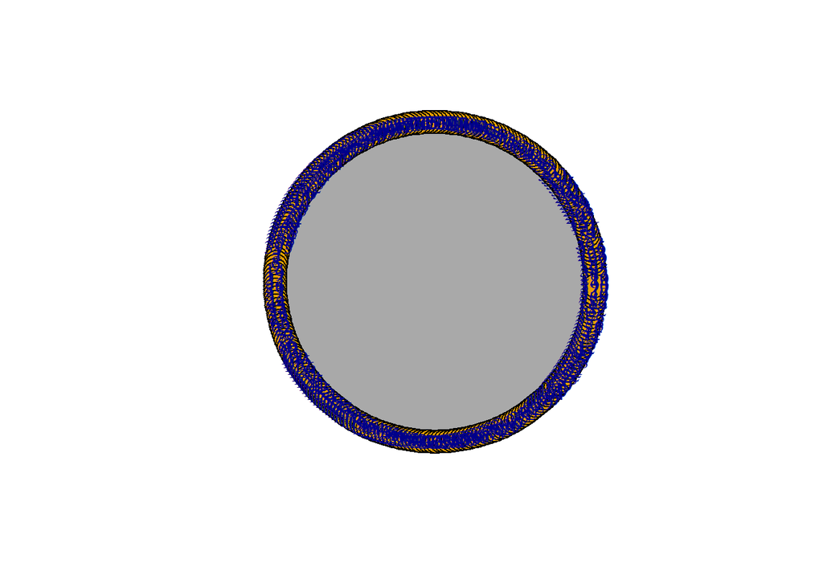

```r
plot(helpnetG, layout=layout_in_circle, edge.width=E(helpnetG)$Avg_Dist.18.)
```

We’ll do more with plotting next time, with a more tractable data set.

(pdf / Rmd)